# tVaramkaushik-titanic

```python
# Core libraries import
import pandas as pd
import numpy as np
import matplotlib.pyplot as plt
import seaborn as sns

# Machine Learning Libraries
from sklearn.model_selection import train_test_split
from sklearn.preprocessing import StandardScaler
from sklearn.linear_model import LogisticRegression
from sklearn.ensemble import RandomForestClassifier
from sklearn.metrics import (
    accuracy_score, precision_score, recall_score, f1_score,
    confusion_matrix, classification_report, roc_curve, roc_auc_score
)

# Configure
sns.set_style("darkgrid")
plt.rcParams['figure.figsize'] = (10, 6)
pd.set_option('display.max_columns', None)
```

## LOAD DATASET

```python
## Load from Seaborn (built-in)
df = sns.load_dataset('titanic')

# Load from Kaggle CSV (if you downloaded it)
# df = pd.read_csv('train.csv')

print("Dataset Shape:", df.shape)
print("\nFirst 5 rows:")

# First 5 Rows
print(df.head())

# Dataset Information
print("\nData Info:")
print(df.info())

# Descriptive Statistics
print("\nDescriptive Statistics:")
print(df.describe().T)
```

```
Dataset Shape: (891, 15)

First 5 rows:
   survived  pclass     sex   age  sibsp  parch     fare embarked  class  \
0         0       3    male  22.0      1      0   7.2500        S  Third
1         1       1  female  38.0      1      0  71.2833        C  First
2         1       3  female  26.0      0      0   7.9250        S  Third
3         1       1  female  35.0      1      0  53.1000        S  First
4         0       3    male  35.0      0      0   8.0500        S  Third

     who  adult_male deck  embark_town alive  alone
0    man        True  NaN  Southampton    no  False
1  woman       False    C    Cherbourg   yes  False
2  woman       False  NaN  Southampton   yes   True
3  woman       False    C  Southampton   yes  False
4    man        True  NaN  Southampton    no   True

Data Info:
<class 'pandas.DataFrame'>
RangeIndex: 891 entries, 0 to 890
Data columns (total 15 columns):
 #   Column       Non-Null Count  Dtype
---  ------       --------------  -----
 0   survived     891 non-null    int64
 1   pclass       891 non-null    int64
 2   sex          891 non-null    str
 3   age          714 non-null    float64
 4   sibsp        891 non-null    int64
 5   parch        891 non-null    int64
 6   fare         891 non-null    float64
 7   embarked     889 non-null    str
 8   class        891 non-null    category
 9   who          891 non-null    str
 10  adult_male   891 non-null    bool
 11  deck         203 non-null    category
 12  embark_town  889 non-null    str
 13  alive        891 non-null    str
 14  alone        891 non-null    bool
dtypes: bool(2), category(2), float64(2), int64(4), str(5)
memory usage: 80.7 KB
None

Descriptive Statistics:
          count       mean        std   min      25%      50%   75%       max
survived  891.0   0.383838   0.486592  0.00   0.0000   0.0000   1.0    1.0000
pclass    891.0   2.308642   0.836071  1.00   2.0000   3.0000   3.0    3.0000
age       714.0  29.699118  14.526497  0.42  20.1250  28.0000  38.0   80.0000
sibsp     891.0   0.523008   1.102743  0.00   0.0000   0.0000   1.0    8.0000
parch     891.0   0.381594   0.806057  0.00   0.0000   0.0000   0.0    6.0000
fare      891.0  32.204208  49.693429  0.00   7.9104  14.4542  31.0  512.3292
```

## DATA PREPROCESSING & CLEANING

```
Missing Values BEFORE cleaning:
age            177
embarked         2
deck           688
embark_town      2
dtype: int64

Missing Values AFTER cleaning:
Series([], dtype: int64)
No missing values

Rows after outlier removal: 718
Survival rate: 33.43%

Training Set: 574 samples
Test Set:     144 samples

 Preprocessing complete. No data leakage.
Missing values in X_train:
pclass         0
sex            0
age            0
fare           0
sibsp          0
parch          0
family_size    0
alone          0
embarked       0
dtype: int64

Missing values in X_test:
pclass         0
sex            0
age            0
fare           0
sibsp          0
parch          0
family_size    0
alone          0
embarked       0
dtype: int64
Model trained successfully!
First 10 predictions:
[0 1 1 1 1 0 0 0 0 0]
Accuracy: 0.7777777777777778
              precision    recall  f1-score   support

           0       0.81      0.88      0.84        96
           1       0.70      0.58      0.64        48

    accuracy                           0.78       144
   macro avg       0.75      0.73      0.74       144
weighted avg       0.77      0.78      0.77       144
```

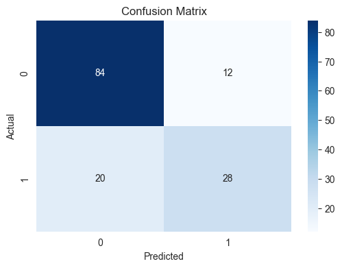

```python
df = sns.load_dataset('titanic')

# Check Missing Values (before any cleaning)
print("\nMissing Values BEFORE cleaning:")
missing = df.isnull().sum()
print(missing[missing > 0])

# Drop Unnecessary Columns
df = df.drop(columns=['deck', 'embark_town', 'class', 'who', 'adult_male', 'alive'], errors='ignore')

# Handle Missing Values
df['age']  = df['age'].fillna(df['age'].median())
df['fare'] = df['fare'].fillna(df['fare'].median())

# Safe embarked fill using .iloc[0] instead of [0]
embarked_mode = df['embarked'].mode()
if not embarked_mode.empty:
    df['embarked'] = df['embarked'].fillna(embarked_mode.iloc[0])  # ← .iloc[0] is safe
else:
    df['embarked'] = df['embarked'].fillna('S')  # fallback to most common port
    print("embarked mode was empty — filled with S")

# Verify no missing values remain
print("\nMissing Values AFTER cleaning:")
print(df.isnull().sum()[df.isnull().sum() > 0])
print("No missing values" if df.isnull().sum().sum() == 0 else "Still has NaNs!")

# Data Type Conversion
df['sex']      = df['sex'].map({'male': 0, 'female': 1})
df['embarked'] = df['embarked'].map({'S': 0, 'C': 1, 'Q': 2})


# Feature Engineering
df['family_size'] = df['sibsp'] + df['parch']
df['alone'] = (df['family_size'] == 0).astype(int)

# Outlier Removal (IQR)
def remove_outliers_iqr(data, column):
    Q1    = data[column].quantile(0.25)
    Q3    = data[column].quantile(0.75)
    IQR   = Q3 - Q1
    lower = Q1 - 1.5 * IQR
    upper = Q3 + 1.5 * IQR
    return data[(data[column] >= lower) & (data[column] <= upper)]

df = remove_outliers_iqr(df, 'age')
df = remove_outliers_iqr(df, 'fare')

print(f"\nRows after outlier removal: {df.shape[0]}")
print(f"Survival rate: {df['survived'].mean():.2%}")

# Define Features & Target
X = df[['pclass', 'sex', 'age', 'fare', 'sibsp', 'parch', 'family_size', 'alone', 'embarked']]
y = df['survived']

# Split FIRST, then Scale
X_train, X_test, y_train, y_test = train_test_split(
    X, y, test_size=0.2, random_state=42, stratify=y
)

print(f"\nTraining Set: {X_train.shape[0]} samples")
print(f"Test Set:     {X_test.shape[0]} samples")

scaler         = StandardScaler()
numerical_cols = ['age', 'fare', 'sibsp', 'parch', 'family_size']

X_train = X_train.copy()
X_test  = X_test.copy()

X_train[numerical_cols] = scaler.fit_transform(X_train[numerical_cols])
X_test[numerical_cols]  = scaler.transform(X_test[numerical_cols])

print("\n Preprocessing complete. No data leakage.")
# MODEL BUILDING
from sklearn.linear_model import LogisticRegression

print("Missing values in X_train:")
print(X_train.isnull().sum())

print("\nMissing values in X_test:")
print(X_test.isnull().sum())

model = LogisticRegression(max_iter=1000)
model.fit(X_train, y_train)

print("Model trained successfully!")

# PREDICTIONS
y_pred = model.predict(X_test)

print("First 10 predictions:")
print(y_pred[:10])

# MODEL EVALUATION
from sklearn.metrics import accuracy_score, confusion_matrix
import seaborn as sns
import matplotlib.pyplot as plt

accuracy = accuracy_score(y_test, y_pred)
print("Accuracy:", accuracy)

from sklearn.metrics import classification_report
print(classification_report(y_test, y_pred))

cm = confusion_matrix(y_test, y_pred)

plt.figure(figsize=(6, 4))
sns.heatmap(cm, annot=True, fmt='d', cmap='Blues')
plt.title("Confusion Matrix")
plt.xlabel("Predicted")
plt.ylabel("Actual")
plt.show()
```

## EXPLORATORY DATA ANALYSIS (EDA)

```
Survival Distribution:
survived
0    478
1    240
Name: count, dtype: int64
Survival Rate: 33.43%
```

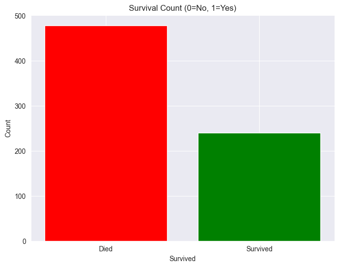

```python
# Target Variable Distribution
print("\nSurvival Distribution:")
print(df['survived'].value_counts())
print(f"Survival Rate: {df['survived'].mean():.2%}")

plt.figure(figsize=(8, 6))
survival_counts = df['survived'].value_counts().sort_index()
plt.bar(survival_counts.index, survival_counts.values, color=['red', 'green'])
plt.title('Survival Count (0=No, 1=Yes)')
plt.xlabel('Survived')
plt.ylabel('Count')
plt.xticks([0, 1], ['Died', 'Survived'])
plt.show()
```

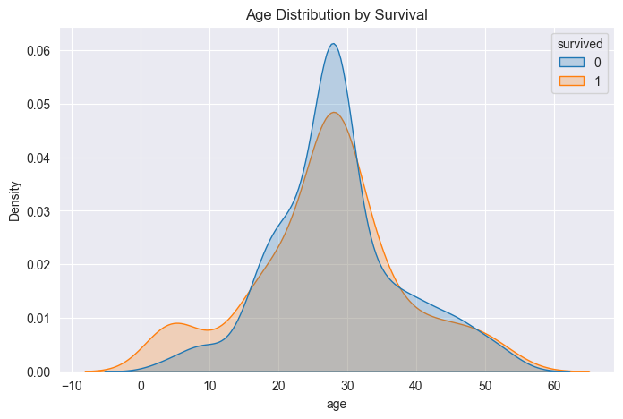

```python
# Survival by Sex
plt.figure(figsize=(8,5))
sns.kdeplot(data=df, x='age', hue='survived', fill=True, common_norm=False)
plt.title("Age Distribution by Survival")
plt.show()
```

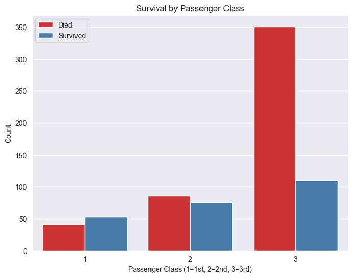

```python
# Survival by Passenger Class (pclass)
plt.figure(figsize=(8, 6))
sns.countplot(x='pclass', hue='survived', data=df, palette='Set1')
plt.title('Survival by Passenger Class')
plt.xlabel('Passenger Class (1=1st, 2=2nd, 3=3rd)')
plt.ylabel('Count')
plt.legend(['Died', 'Survived'])
plt.show()
```

[figure not shown]

```python
# Age Distribution by Survival
plt.figure(figsize=(10, 6))
sns.kdeplot(x='age', hue='survived', data=df, fill=True,
            palette=['red', 'green'], alpha=0.5)
plt.title('Age Distribution by Survival')
plt.xlabel('Age (normalized)')
plt.ylabel('Density')
plt.legend(['Died', 'Survived'])
plt.show()
```

[figure not shown]

```python
# Fare Distribution by Survival
plt.figure(figsize=(10, 6))
sns.kdeplot(x='fare', hue='survived', data=df, fill=True,
            palette=['red', 'green'], alpha=0.5)
plt.title('Fare Distribution by Survival')
plt.xlabel('Fare (normalized)')
plt.ylabel('Density')
plt.legend(['Died', 'Survived'])
plt.show()
```

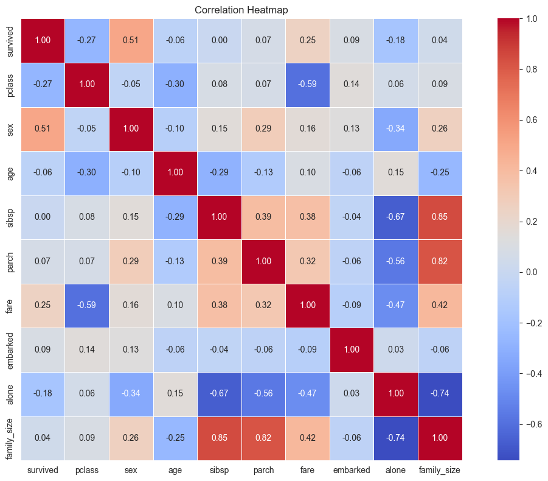

```
Correlation with Survival:
sex            0.509660
fare           0.247519
embarked       0.094293
parch          0.070732
family_size    0.042121
sibsp          0.002503
age           -0.063606
alone         -0.175020
pclass        -0.268318
Name: survived, dtype: float64
```

```python
# Correlation Matrix
corr_matrix = df.corr(numeric_only=True)

plt.figure(figsize=(12, 8))
sns.heatmap(corr_matrix, annot=True, fmt='.2f', cmap='coolwarm',
            linewidths=0.5, square=True)
plt.title('Correlation Heatmap')
plt.tight_layout()
plt.show()

print("\nCorrelation with Survival:")
print(corr_matrix['survived'].drop('survived').sort_values(ascending=False))
```

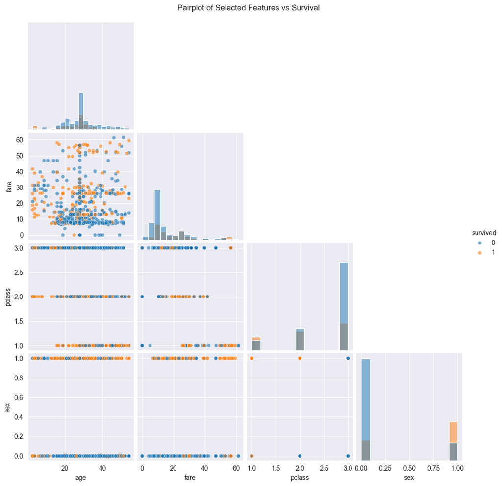

```python
# Pairplot on selected features
pairplot_cols = ['age', 'fare', 'pclass', 'sex', 'survived']

sns.pairplot(
    df[pairplot_cols],
    hue='survived',
    corner=True,
    diag_kind='hist',
    plot_kws={'alpha': 0.6, 's': 30}
)
plt.suptitle('Pairplot of Selected Features vs Survival', y=1.02)
plt.show()
```

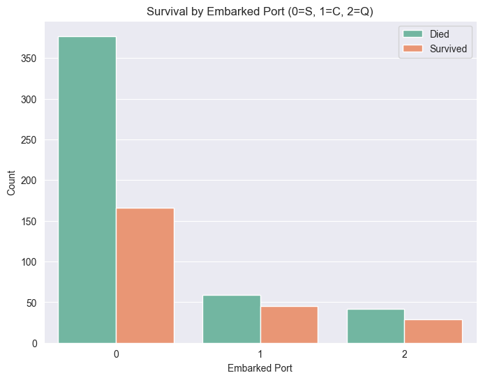

```python
# Survival by Embarked Port
plt.figure(figsize=(8, 6))
sns.countplot(x='embarked', hue='survived', data=df, palette='Set2')
plt.title('Survival by Embarked Port (0=S, 1=C, 2=Q)')
plt.xlabel('Embarked Port')
plt.ylabel('Count')
plt.legend(['Died', 'Survived'])
plt.show()
```

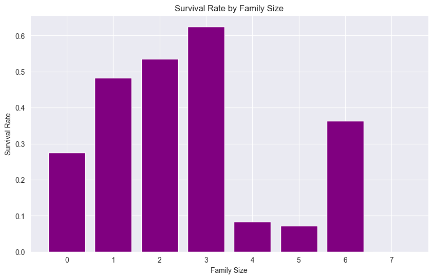

```python
# Survival by Family Size
plt.figure(figsize=(10, 6))
family_survival_rate = df.groupby('family_size')['survived'].mean()
plt.bar(family_survival_rate.index, family_survival_rate.values, color='purple')
plt.title('Survival Rate by Family Size')
plt.xlabel('Family Size')
plt.ylabel('Survival Rate')
plt.show()
```

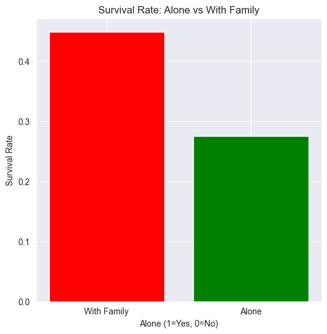

```python
# Survival by Alone Status
plt.figure(figsize=(6, 6))
alone_survival = df.groupby('alone')['survived'].mean()
plt.bar(alone_survival.index, alone_survival.values, color=['red', 'green'])
plt.title('Survival Rate: Alone vs With Family')
plt.xlabel('Alone (1=Yes, 0=No)')
plt.ylabel('Survival Rate')
plt.xticks([0, 1], ['With Family', 'Alone'])
plt.show()
```

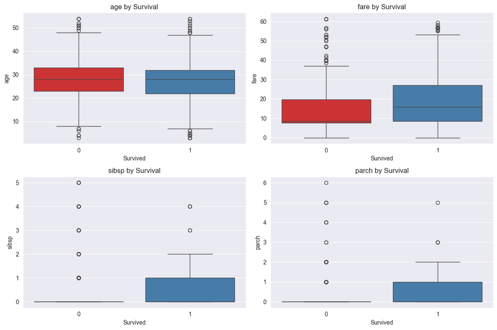

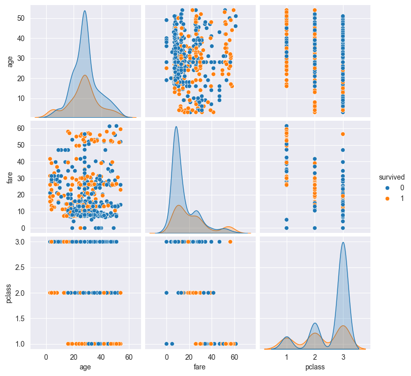

```python
# Box Plots for Key Features
plt.figure(figsize=(12, 8))
for idx, feature in enumerate(['age', 'fare', 'sibsp', 'parch'], 1):
    plt.subplot(2, 2, idx)
    sns.boxplot(x='survived', y=feature, data=df, palette='Set1', hue='survived', legend=False)
    plt.title(f'{feature} by Survival')
    plt.xlabel('Survived')

plt.tight_layout()
plt.show()

# Pair Plot
sns.pairplot(
    df[['survived', 'age', 'fare', 'pclass']],
    hue='survived'
)

plt.show()
```

## EDA Summary and Key Insights

- Females and passengers in 1st class show a much higher survival rate than males and those in 3rd class.
- Passengers who paid higher fares tend to survive more often, suggesting that ticket price (and thus socio-economic status) was positively related to survival.
- Age shows a weaker pattern, but there is some indication that younger passengers had slightly better survival chances than older ones.
- Traveling with family (non-zero family_size) appears to help survival compared to being completely alone, although the effect is not as strong as sex or class.
- The correlation heatmap and feature importance later both indicate that sex, passenger class (pclass), and fare are among the most influential features related to survival.

## MODEL BUILDING (Binary Classification)

```python
# X_train, X_test, y_train, y_test already prepared in Cell 4
print(f"Training Set: {X_train.shape[0]} samples")
print(f"Test Set:     {X_test.shape[0]} samples")
```

```
Training Set: 574 samples
Test Set:     144 samples
```

```python
# Model 1: Logistic Regression
log_model = LogisticRegression(max_iter=1000, random_state=42)
log_model.fit(X_train, y_train)

y_pred_log = log_model.predict(X_test)
y_pred_proba_log = log_model.predict_proba(X_test)[:, 1]

log_acc  = accuracy_score(y_test, y_pred_log)
log_prec = precision_score(y_test, y_pred_log)
log_rec  = recall_score(y_test, y_pred_log)
log_f1   = f1_score(y_test, y_pred_log)
log_auc  = roc_auc_score(y_test, y_pred_proba_log)

print("\n=== Logistic Regression ===")
print(f"Accuracy:  {log_acc:.3f}")
print(f"Precision: {log_prec:.3f}")
print(f"Recall:    {log_rec:.3f}")
print(f"F1-score:  {log_f1:.3f}")
print(f"ROC-AUC:   {log_auc:.3f}")
print("\nClassification Report:")
print(classification_report(y_test, y_pred_log))
```

```
=== Logistic Regression ===
Accuracy:  0.778
Precision: 0.700
Recall:    0.583
F1-score:  0.636
ROC-AUC:   0.835

Classification Report:
              precision    recall  f1-score   support

           0       0.81      0.88      0.84        96
           1       0.70      0.58      0.64        48

    accuracy                           0.78       144
   macro avg       0.75      0.73      0.74       144
weighted avg       0.77      0.78      0.77       144
```

```python
# Random Forest Classifier (with class_weight to fix low recall)
rf_model = RandomForestClassifier(
    n_estimators=100, random_state=42, max_depth=5, class_weight='balanced'
)
rf_model.fit(X_train, y_train)

y_pred_rf = rf_model.predict(X_test)
y_pred_proba_rf = rf_model.predict_proba(X_test)[:, 1]

rf_acc  = accuracy_score(y_test, y_pred_rf)
rf_prec = precision_score(y_test, y_pred_rf)
rf_rec  = recall_score(y_test, y_pred_rf)
rf_f1   = f1_score(y_test, y_pred_rf)
rf_auc  = roc_auc_score(y_test, y_pred_proba_rf)

print("\n=== Random Forest Classifier ===")
print(f"Accuracy:  {rf_acc:.3f}")
print(f"Precision: {rf_prec:.3f}")
print(f"Recall:    {rf_rec:.3f}")
print(f"F1-score:  {rf_f1:.3f}")
print(f"ROC-AUC:   {rf_auc:.3f}")
print("\nClassification Report:")
print(classification_report(y_test, y_pred_rf))
```

```
=== Random Forest Classifier ===
Accuracy:  0.833
Precision: 0.722
Recall:    0.812
F1-score:  0.765
ROC-AUC:   0.857

Classification Report:
              precision    recall  f1-score   support

           0       0.90      0.84      0.87        96
           1       0.72      0.81      0.76        48

    accuracy                           0.83       144
   macro avg       0.81      0.83      0.82       144
weighted avg       0.84      0.83      0.84       144
```

```python
# Model Comparison
print("\n=== Model Comparison ===")
comparison = pd.DataFrame({
    'Model':     ['Logistic Regression', 'Random Forest'],
    'Accuracy':  [log_acc,  rf_acc],
    'Precision': [log_prec, rf_prec],
    'Recall':    [log_rec,  rf_rec],
    'F1-Score':  [log_f1,   rf_f1],
    'ROC-AUC':   [log_auc,  rf_auc]
})
print(comparison.to_string(index=False))
```

```
=== Model Comparison ===
              Model  Accuracy  Precision   Recall  F1-Score  ROC-AUC
Logistic Regression  0.777778   0.700000 0.583333  0.636364 0.834635
      Random Forest  0.833333   0.722222 0.812500  0.764706 0.857422
```

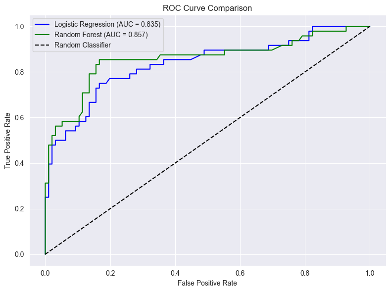

```python
# ROC Curve Plot
fpr_log, tpr_log, _ = roc_curve(y_test, y_pred_proba_log)
fpr_rf,  tpr_rf,  _ = roc_curve(y_test, y_pred_proba_rf)

plt.figure(figsize=(8, 6))
plt.plot(fpr_log, tpr_log, label=f'Logistic Regression (AUC = {log_auc:.3f})', color='blue')
plt.plot(fpr_rf,  tpr_rf,  label=f'Random Forest (AUC = {rf_auc:.3f})',        color='green')
plt.plot([0, 1], [0, 1], 'k--', label='Random Classifier')
plt.xlabel('False Positive Rate')
plt.ylabel('True Positive Rate')
plt.title('ROC Curve Comparison')
plt.legend()
plt.tight_layout()
plt.show()
```

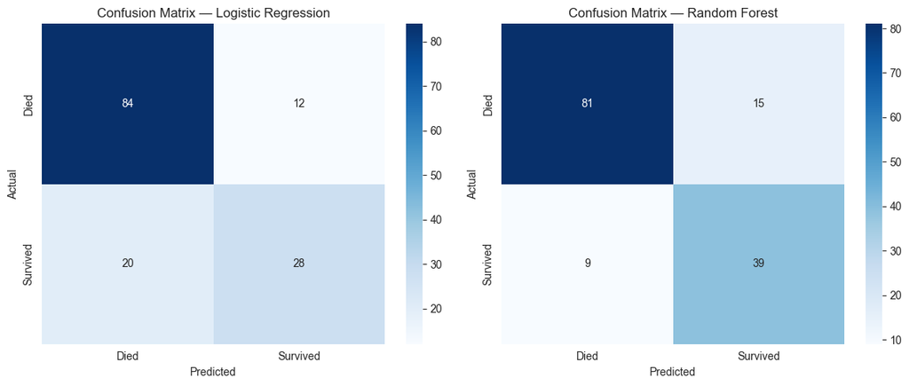

```python
# Confusion Matrix
fig, axes = plt.subplots(1, 2, figsize=(12, 5))
for ax, model_name, y_pred in zip(
    axes,
    ['Logistic Regression', 'Random Forest'],
    [y_pred_log, y_pred_rf]
):
    cm = confusion_matrix(y_test, y_pred)
    sns.heatmap(cm, annot=True, fmt='d', cmap='Blues', ax=ax,
                xticklabels=['Died', 'Survived'],
                yticklabels=['Died', 'Survived'])
    ax.set_title(f'Confusion Matrix — {model_name}')
    ax.set_xlabel('Predicted')
    ax.set_ylabel('Actual')
plt.tight_layout()
plt.show()
```

```
Top 5 Important Features:
       feature  importance
1          sex    0.471427
3         fare    0.175053
2          age    0.104888
0       pclass    0.096887
6  family_size    0.063511
```

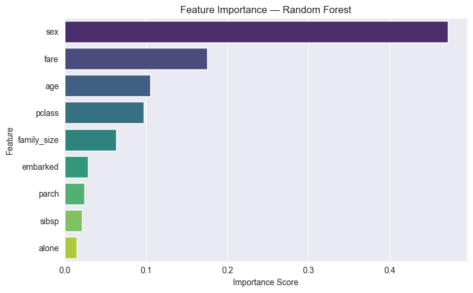

```python
# Feature Importance (Random Forest)
feat_imp = pd.DataFrame({
    'feature':    X_train.columns,
    'importance': rf_model.feature_importances_
}).sort_values('importance', ascending=False)

print("\nTop 5 Important Features:")
print(feat_imp.head())

plt.figure(figsize=(8, 5))
sns.barplot(x='importance', y='feature', data=feat_imp,
            hue='feature', palette='viridis', legend=False)
plt.title('Feature Importance — Random Forest')
plt.xlabel('Importance Score')
plt.ylabel('Feature')
plt.tight_layout()
plt.show()
```

## Model Comparison and Conclusion

- Both Logistic Regression and Random Forest perform reasonably well, but the Random Forest model achieves higher overall performance.
- Random Forest has better recall and F1-score for the positive class (survived), which means it catches more of the actual survivors compared to Logistic Regression.
- The ROC-AUC score is also slightly higher for Random Forest, indicating better ranking of survival probabilities overall.
- Feature importance from Random Forest confirms that sex, fare, age, and passenger class are the most important predictors, which matches our EDA findings.
- In this project, Random Forest is the preferred model because it balances accuracy with stronger recall and captures non-linear relationships in the data.